# Clustering

## Cluster analysis

Grouping objects so that objects in the same group are more similar to each other than to objects of other groups.

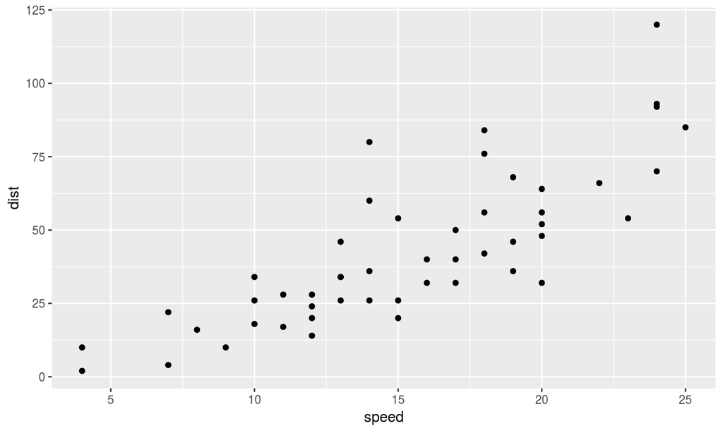

## Cluster analysis

Grouping objects so that objects in the same group are more similar to each other than to objects of other groups.

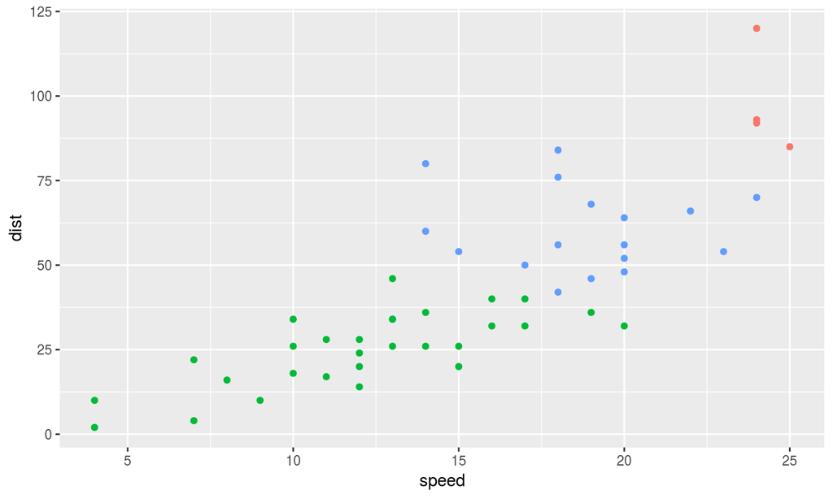

## Agglomerative Hierarchical Clustering

Clusters: 2  
Input: 2, 8, 4, 11, 3

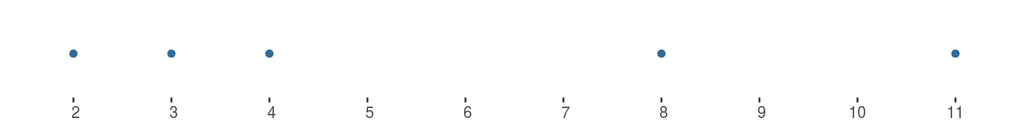

## Agglomerative Hierarchical Clustering

Clusters: 2  
Input: 2, 8, 4, 11, 3

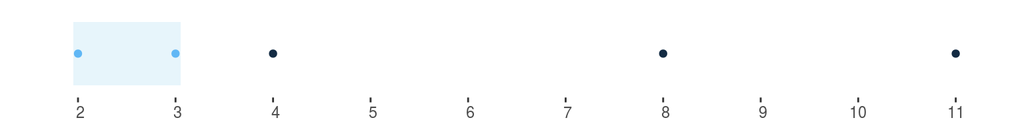

## Agglomerative Hierarchical Clustering

Clusters: 2  
Input: 2, 8, 4, 11, 3

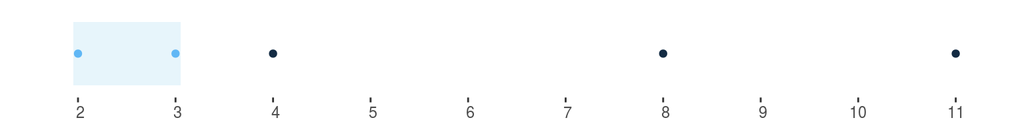

Linkage:

```
single([2,3], [4]) = 1
complete([2,3], [4]) = 2
centroid([2,3], [4]) = 1.5
```

## Agglomerative Hierarchical Clustering

Clusters: 2  
Input: 2, 8, 4, 11, 3

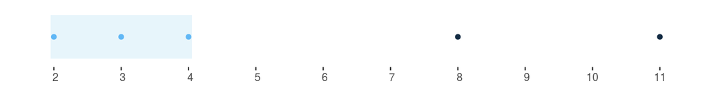

Linkage:

```
single([2,3], [4]) = 1
complete([2,3], [4]) = 2
centroid([2,3], [4]) = 1.5
```

## Agglomerative Hierarchical Clustering

Clusters: 2  
Input: 2, 8, 4, 11, 3

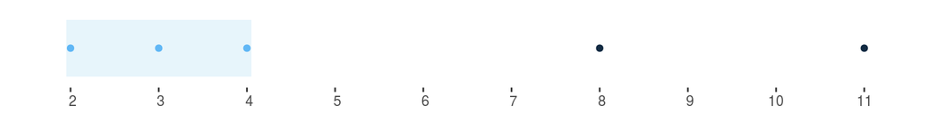

Linkage:

```
single([2,3,4], [8]) = 4, single([8], [11]) = 3
complete([2,3,4], [8]) = 6, complete([8], [11]) = 3
centroid([2,3,4], [8]) = 5, centroid([8], [11]) = 3
```

## Agglomerative Hierarchical Clustering

Clusters: 2  
Input: 2, 8, 4, 11, 3

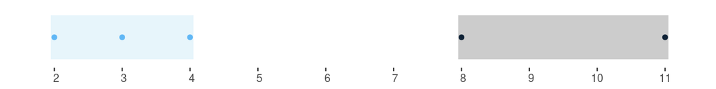

Linkage:

```
single([2,3,4], [8]) = 4, single([8], [11]) = 3
complete([2,3,4], [8]) = 6, complete([8], [11]) = 3
centroid([2,3,4], [8]) = 5, centroid([8], [11]) = 3
```

## K-means

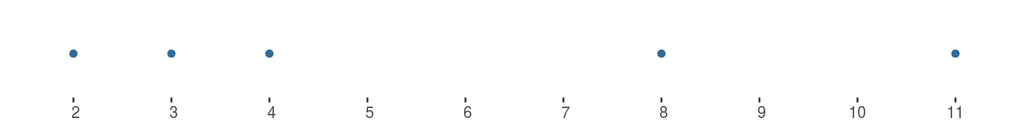

## K-means

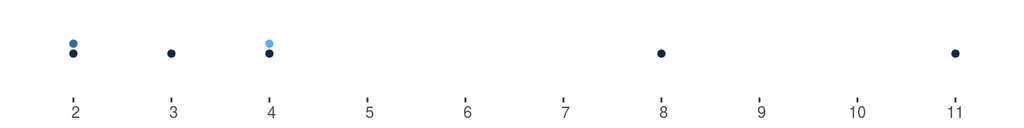

Initial centroids: A=2, B=4

## K-means

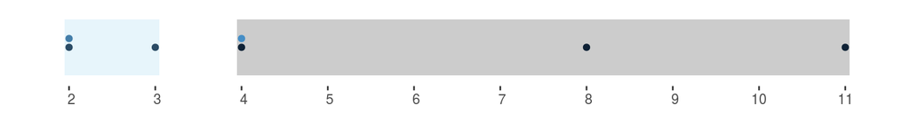

Initial centroids: A=2, B=4

## K-means

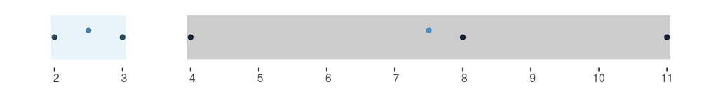

## K-means

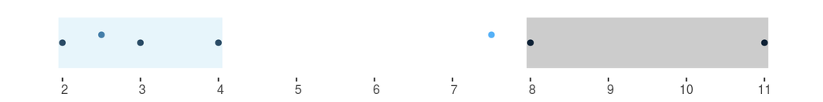

## K-means

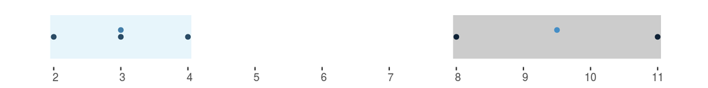

## K-means

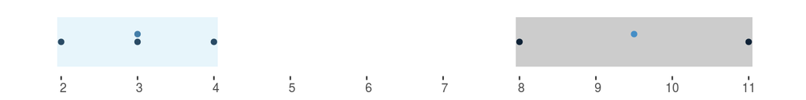

Centroids/membership is stable

## Clustering in two dimensions

**Euclidian distance**

\(d_\epsilon(X,Y) = \sqrt{\big|X_0 - Y_0\big|^2 + \big|X_1 - Y_1\big|^2 + ... + \big|X_n - Y_n\big|^2}\)

**p-norm**

- Manhattan (\(p=1\))
- Euclidian (\(p=2\)) -Chebyshev (\(p=∞\))

Other: **Levenstein-Damerau** (strings), graph distances